# Extending SORT to Predict Morbidity using the SOuRCe Cohort

Danny Wong, Matt Oliver & Ramani Moonesinghe

Tuesday, February 16, 2016

## Summary

- After cleaning the data, I fitted regression models with POMS (binary: TRUE or FALSE) as the outcome measure with predictor variables derived from the original SORT model.
- **Regression Model 1**: POMS Day 7 or 8 outcome, Age continuous predictor, no internal validation.
- **Regression Model 2**: POMS Day 7 or 8 outcome, predictor variables exactly as in original SORT model, no internal validation.
- **Regression Model 3**: POMS Day 7 or 8 outcome, predictor variables exactly as in original SORT model, internal validation.
- **Regression Model 4**: POMS Day 7 or 8 outcome, predictor variables pre-weighted with the coefficients used in the original SORT model *before* fitting model, internal validation.
- **Regression Model 5**: Alternative outcome measure - Readmission within 30 days, predictor variables as in Model 3, internal validation.
- **Regression Model 6**: POMS Day 14 or 15 outcome, predictor variables exactly as in Model 3, internal validation.
- **Regression Model 7**: POMS Day 7 or 8 outcome, restricted predictor variable with only Colorectal surgery as the dummy variable for high-risk surgical specialties, otherwise same as Model 3, internal validation.
- **Regression Model 8**: POMS Day 7 or 8 outcome, Surgical Specialty as factors (6 categories, 5 dummy variables), otherwise same as Model 7, internal validation.
- **Regression Model 9**: POMS Day 7 or 8 outcome, ASA = 2 or 3 or >=4, otherwise same as Model 8, internal validation.
- **Regression Model 10**: POMS Day 7 or 8 outcome, predictor variable for opspecialty is now a factor with 6 categories (5 dummy variables) instead of “high-risk” surgical specialties, and ASA is now a continuous variable, otherwise same as Model 7, internal validation.
- **Regression Model 11**: POMS Day 7 or 8 outcome, predictor variable for opspecialty is now a factor with 6 categories (5 dummy variables) instead of “high-risk” surgical specialties, and ASA and Age are now continuous variables, and added interaction between age and specialty, otherwise same as Model 10, internal validation.
- **NB**: Where the ROC curves were plotted, the dotted lines in red signify the ROC curve for p-POSSUM(morbidity), overlaid for comparison, the solid lines signify the fitted model being tested. For the sake of brevity, I do not show the source code after Model 4.

## Introduction

Matt Oliver has kindly provided some data that he has cleaned from the SOuRCe database of >1900 patients who underwent surgery. The purpose of our project is to calibrate and validate the risk calculation tools. He has already done this with mortality using SORT and with pPOSSUM. We are going to see if we can also do this for morbidity using POMS.

## Data tidying and cleaning

First we load the data that has been cleaned in the SOuRCeDataCleaning.Rmd file

```r
library(knitr)
purl("SOuRCeDataCleaning.Rmd")
read_chunk("SOuRCeDataCleaning.R")
unlink("SOuRCeDataCleaning.R")
```

## Analysis

### Mortality external validation

The first step is to externally validate the SORT model for mortality against the data

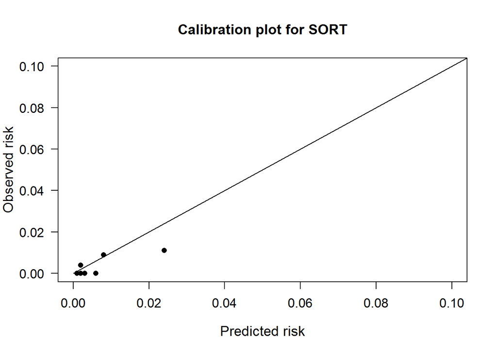

```r
#Load the data, this is a workaround because there're problems with running
#plotCalibration with using the existing data_clean dataframe, must be something
#to do with how the data is stored in R (vector or matrix or otherwise)
data_clean <- read.csv("data/SOuRCedata_clean.csv")

#Test SORT with the dataset
library(PredictABEL)

HL1 <- plotCalibration(data_clean,
                       cOutcome = match("mort30", colnames(data_clean)),
                       predRisk = data_clean$sort_mort,
                       rangeaxis = c(0,0.1),
                       plottitle = "Calibration plot for SORT")
```

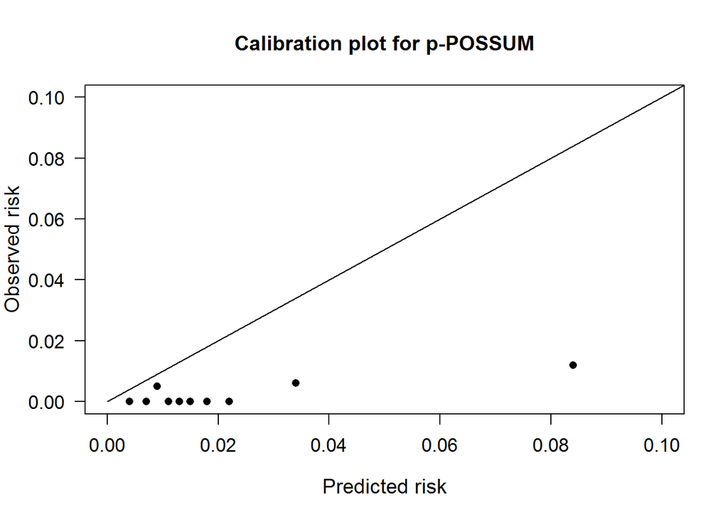

```r
HL2 <- plotCalibration(data_clean,
                       cOutcome = match("mort30", colnames(data_clean)),
                       predRisk = data_clean$p_possmort,
                       rangeaxis = c(0,0.1),
                       plottitle = "Calibration plot for p-POSSUM")
```

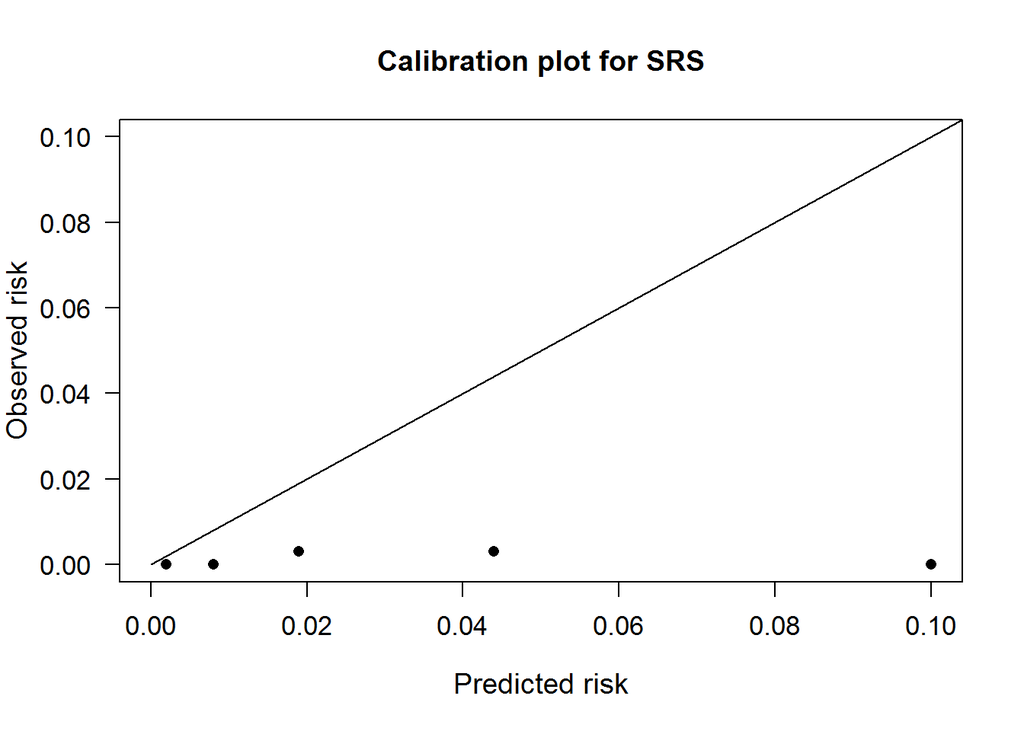

```r
HL3 <- plotCalibration(data_clean,
                       cOutcome = match("mort30", colnames(data_clean)),
                       predRisk = data_clean$srs_mort,
                       rangeaxis = c(0,0.1),
                       plottitle = "Calibration plot for SRS")
```

```r
#Let's overlay the ROC curve over the ROC curve for p-POSSUM
plotROC(data = data_clean,
        cOutcome = match("mort30", colnames(data_clean)),
        predrisk = cbind(data_clean$sort_mort,
                         data_clean$p_possmort,
                         data_clean$srs_mort),
        plottitle = "SORT vs p-POSSUM & SRS"
        #labels = c("SORT", "p-POSSUM", "SRS")
        )
```

```
## AUC [95% CI] for the model 1 :  0.793 [ 0.554  -  1.031 ]
## AUC [95% CI] for the model 2 :  0.791 [ 0.509  -  1.073 ]
## AUC [95% CI] for the model 3 :  0.639 [ 0.491  -  0.787 ]
```

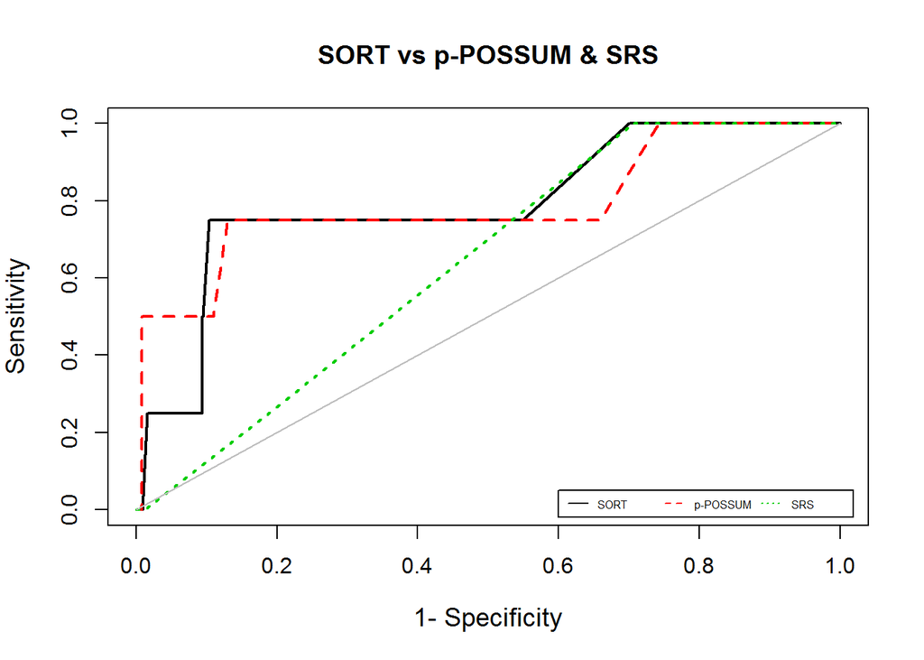

```r
legend("bottomright", inset = c(0.02,0.02), legend = c("SORT","p-POSSUM","SRS"),
       col = c(17,18,19), lty = c(1,2,3),
       horiz = TRUE, cex = 0.5)
```

```r
#Let's compare whether the new model is as good as POSSUM in discrimination
library(pROC)

#Create the ROC objects
roc_SORT <- roc(data_clean$mort30 ~ data_clean$sort_mort, plot=FALSE, auc=TRUE, ci=TRUE)
roc_pPOSSUM <- roc(data_clean$mort30 ~ data_clean$p_possmort, plot=FALSE, auc=TRUE, ci=TRUE)
roc_SRS <- roc(data_clean$mort30 ~ data_clean$srs_mort, plot=FALSE, auc=TRUE, ci=TRUE)

#Test the ROC objects against each other
roc.test(roc_SORT, roc_pPOSSUM)
```

```
##
##  DeLong's test for two correlated ROC curves
##
## data:  roc_SORT and roc_pPOSSUM
## Z = 0.028709, p-value = 0.9771
## alternative hypothesis: true difference in AUC is not equal to 0
## sample estimates:
## AUC of roc1 AUC of roc2
##   0.7925357   0.7910263
```

```r
roc.test(roc_SORT, roc_SRS)
```

```
##
##  DeLong's test for two correlated ROC curves
##
## data:  roc_SORT and roc_SRS
## Z = 1.2121, p-value = 0.2255
## alternative hypothesis: true difference in AUC is not equal to 0
## sample estimates:
## AUC of roc1 AUC of roc2
##   0.7925357   0.6389956
```

### Day 7 or 8 POMS

Now it looks like we are ready to do some analysis looking at Day 7 or 8 POMS as outcome measures.

```r
#Let's get an overview of the data
describe(join7)
```

```
## join7
##
##  53  Variables      1583  Observations
## ---------------------------------------------------------------------------
## poms_id
##        n  missing distinct
##      632      951      632
##
## lowest : 004e6778-08cc-4985-9e1b-fc85622de277 0055f57f-bda3-4f77-b8fa-cf126fdc814a 01028b80-1d58-45ed-b4ea-6fea7ac5d935 0248aa0b-38ba-4eef-bbe8-7e79c1bb7e1a 024be601-de89-488b-b35f-2a85fdb630dc
## highest: fec3f147-5f60-4c4b-8a71-a2358ea2f35b fee6a4a2-6ce1-4995-8fa6-1df682442a53 ff4c36ef-a972-45bb-a334-80431cba81c8 ff8c6d7c-1924-42e5-a9b3-ceeffb6366ff ff9890a7-bec1-499d-afa1-00e5f189bca0
## ---------------------------------------------------------------------------
## adm_id
##        n  missing distinct
##     1583        0     1583
##
## lowest : 00422cff-ddbe-49e6-a2d9-f4680c0945c2  00bea38f-af7b-4f5f-9655-1ab134c95571  00cea437-fd5a-45d4-859d-ddd7f48f3199  01125a5f-814c-4120-a298-ae6f27d43ef5  012d095b-6cf9-4b06-b7de-50b6d72277de
## highest: ff7964aa-a0c5-49c3-99dc-b39df7d021f2  ff8455e0-44e3-470d-8e86-0893cc101bc0  ff962ad5-22e6-42e4-b35b-3e6cc03ea022  ff9d4b2f-08b0-4a74-8c24-af45b0472a18  ffd1beee-09b8-4203-836b-2bd08ac472f5
## ---------------------------------------------------------------------------
## poms_day
##        n  missing distinct     Info     Mean      Gmd
##      632      951        2     0.44    7.179   0.2941
##
## 7 (519, 0.821), 8 (113, 0.179)
## ---------------------------------------------------------------------------
## pulm
##        n  missing distinct
##     1583        0        2
##
## FALSE (1509, 0.953), TRUE (74, 0.047)
## ---------------------------------------------------------------------------
## inf
##        n  missing distinct
##     1583        0        2
##
## FALSE (1455, 0.919), TRUE (128, 0.081)
## ---------------------------------------------------------------------------
## renal
##        n  missing distinct
##     1583        0        2
##
```

[output cut: 298 more lines]

```
## srs_mort
##        n  missing distinct     Info     Mean      Gmd
##     1583        0        8    0.852  0.02048  0.01469
##
## lowest : 0.0006818628 0.0015780281 0.0036477148 0.0084090681 0.0192652326
## highest: 0.0084090681 0.0192652326 0.0435216350 0.0953494649 0.1962340564
##
## Value      0.0006818628 0.0015780281 0.0036477148 0.0084090681
## Frequency            38           60          103          274
## Proportion        0.024        0.038        0.065        0.173
##
## Value      0.0192652326 0.0435216350 0.0953494649 0.1962340564
## Frequency           816          271           20            1
## Proportion        0.515        0.171        0.013        0.001
## ---------------------------------------------------------------------------
```

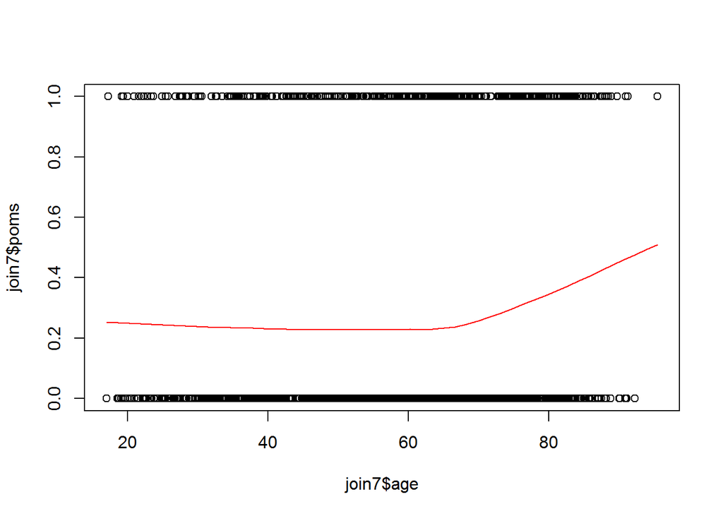

```r
#Let's plot POMS vs the individual predictors add smoothing lines to get a general feel of the data

scatter.smooth(join7$poms ~ join7$age, family = "gaussian",
               lpars = list(col = "red"))
```

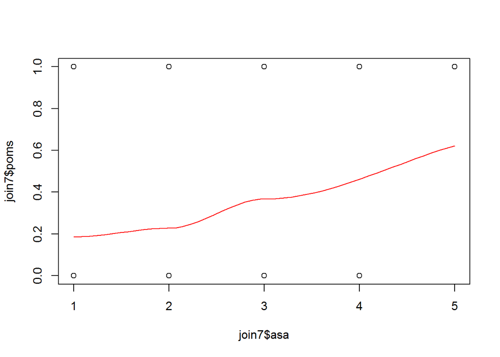

```r
scatter.smooth(join7$poms ~ join7$asa, family = "gaussian",
               lpars = list(col = "red"))
```

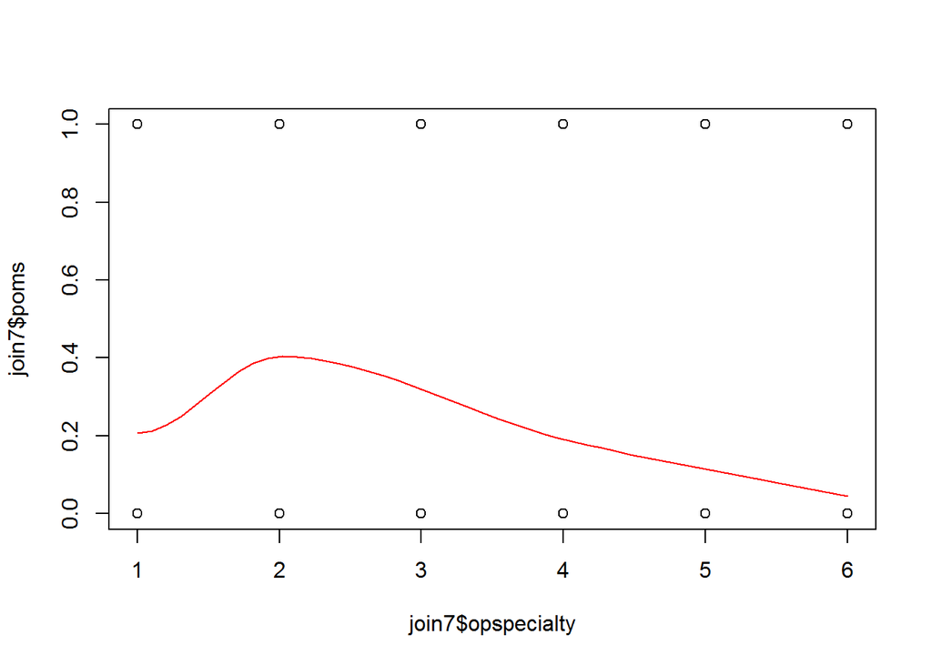

```r
scatter.smooth(join7$poms ~ join7$opspecialty, family = "gaussian",
               lpars = list(col = "red"))
```

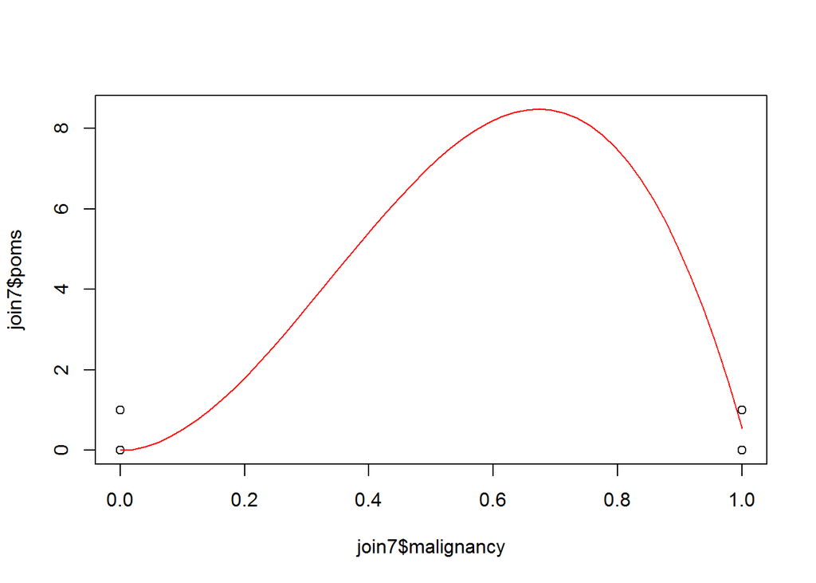

```r
scatter.smooth(join7$poms ~ join7$malignancy, family = "gaussian",
               lpars = list(col = "red"))
```

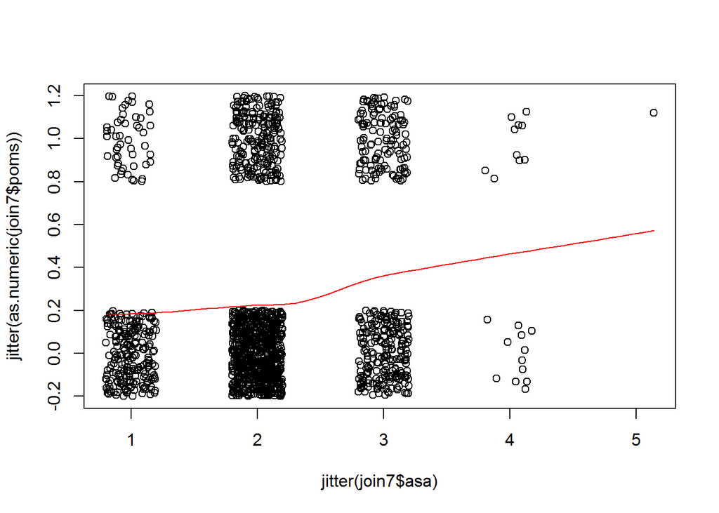

```r
#Might be easier to understand some of the plots with the points jittered
scatter.smooth(jitter(as.numeric(join7$poms)) ~ jitter(join7$asa),
               family = "gaussian", lpars = list(col = "red"))
```

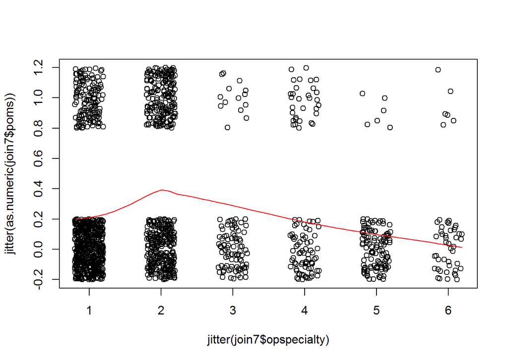

```r
scatter.smooth(jitter(as.numeric(join7$poms)) ~ jitter(join7$opspecialty),
               family = "gaussian", lpars = list(col = "red"))
```

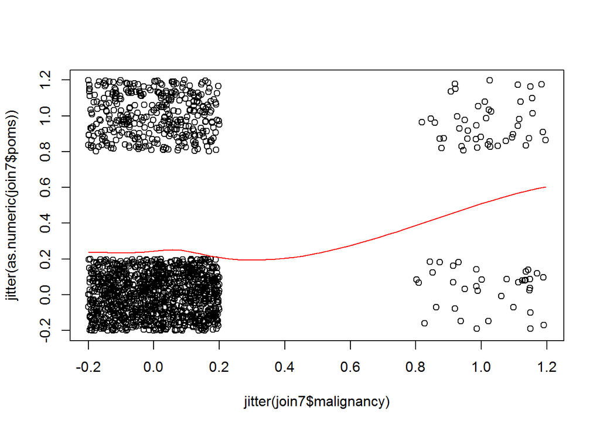

```r
scatter.smooth(jitter(as.numeric(join7$poms)) ~ jitter(join7$malignancy),
               family = "gaussian", lpars = list(col = "red"))
```

#### Regression Models 1 & 2

We will fit some Regression Models. Firstly we will look at the model with age as a continuous variable. In the SORT tool, the risk score binned age into a categorical variable.

```r
#Fit a logistic regression model with the same predictor variables as in SORT, but with any POMS outcome the dependent variable
lr_poms <- glm(poms ~ age +
                 as.factor(asa) +
                 as.factor(opspecialty) +
                 as.factor(op_severity) +
                 as.factor(malignancy),
               data = join7, family = binomial)

summary(lr_poms)
```

```
##
## Call:
## glm(formula = poms ~ age + as.factor(asa) + as.factor(opspecialty) +
##     as.factor(op_severity) + as.factor(malignancy), family = binomial,
##     data = join7)
##
## Deviance Residuals:
##     Min       1Q   Median       3Q      Max
## -1.9548  -0.6554  -0.5603   0.6924   2.9745
##
## Coefficients:
##                           Estimate Std. Error z value Pr(>|z|)
## (Intercept)              -4.983043   0.555480  -8.971  < 2e-16 ***
## age                       0.005609   0.004520   1.241 0.214611
## as.factor(asa)2           0.277849   0.191197   1.453 0.146167
## as.factor(asa)3           1.074435   0.218332   4.921 8.61e-07 ***
## as.factor(asa)4           1.427331   0.504454   2.829 0.004663 **
## as.factor(asa)5          12.654213 324.743789   0.039 0.968917
## as.factor(opspecialty)2   1.641679   0.186901   8.784  < 2e-16 ***
## as.factor(opspecialty)3  -0.568368   0.322841  -1.761 0.078320 .
## as.factor(opspecialty)4   0.180380   0.258682   0.697 0.485612
## as.factor(opspecialty)5  -1.612067   0.442105  -3.646 0.000266 ***
## as.factor(opspecialty)6  -0.270881   0.463594  -0.584 0.559013
## as.factor(op_severity)2   1.298928   0.514030   2.527 0.011506 *
## as.factor(op_severity)4   2.390115   0.459783   5.198 2.01e-07 ***
## as.factor(op_severity)8   2.836190   0.451474   6.282 3.34e-10 ***
## as.factor(malignancy)1    0.750509   0.281624   2.665 0.007700 **
## ---
## Signif. codes:  0 '***' 0.001 '**' 0.01 '*' 0.05 '.' 0.1 ' ' 1
##
## (Dispersion parameter for binomial family taken to be 1)
##
##     Null deviance: 1796.1  on 1582  degrees of freedom
## Residual deviance: 1532.9  on 1568  degrees of freedom
## AIC: 1562.9
##
## Number of Fisher Scoring iterations: 11
```

```r
#Fit another logistic regression model, but this time with the predictor variables in SORT as the discrete variables, eg specific ASA-PS == 3, High risk specialty TRUE, and so on
lr_poms2 <- glm(poms ~ (asa == 3) +
                  (asa == 4) +
                  (asa == 5) +
                  (opspecialty >= 2 & opspecialty < 6) +
                  (op_severity > 7) +
                  malignancy +
                  (age >= 65 & age <80) +
                  (age >= 80),
                data = join7, family = binomial)

summary(lr_poms2)
```

```
##
## Call:
## glm(formula = poms ~ (asa == 3) + (asa == 4) + (asa == 5) + (opspecialty >=
##     2 & opspecialty < 6) + (op_severity > 7) + malignancy + (age >=
##     65 & age < 80) + (age >= 80), family = binomial, data = join7)
##
## Deviance Residuals:
##     Min       1Q   Median       3Q      Max
## -1.5899  -0.7378  -0.6327   0.8149   2.0457
##
## Coefficients:
##                                        Estimate Std. Error z value
## (Intercept)                             -1.9608     0.1948 -10.066
## asa == 3TRUE                             0.6488     0.1371   4.734
## asa == 4TRUE                             0.8416     0.4467   1.884
## asa == 5TRUE                            13.5054   324.7437   0.042
## opspecialty >= 2 & opspecialty < 6TRUE   0.5676     0.1419   4.001
## op_severity > 7TRUE                      0.2312     0.1581   1.462
## malignancy                               1.2223     0.2439   5.011
## age >= 65 & age < 80TRUE                 0.2227     0.1387   1.606
## age >= 80TRUE                            0.6880     0.2050   3.355
##                                        Pr(>|z|)
## (Intercept)                             < 2e-16 ***
## asa == 3TRUE                           2.21e-06 ***
## asa == 4TRUE                           0.059575 .
## asa == 5TRUE                           0.966827
## opspecialty >= 2 & opspecialty < 6TRUE 6.31e-05 ***
## op_severity > 7TRUE                    0.143653
## malignancy                             5.40e-07 ***
## age >= 65 & age < 80TRUE               0.108381
## age >= 80TRUE                          0.000793 ***
## ---
## Signif. codes:  0 '***' 0.001 '**' 0.01 '*' 0.05 '.' 0.1 ' ' 1
##
## (Dispersion parameter for binomial family taken to be 1)
##
##     Null deviance: 1796.1  on 1582  degrees of freedom
## Residual deviance: 1698.1  on 1574  degrees of freedom
## AIC: 1716.1
##
## Number of Fisher Scoring iterations: 11
```

#### Regression Model 3

Theoretically we can do a Logistic Regression with POMS as the outcome variable, however all the cases in the SOuRCe dataset are Elective cases, so we lose one of the dependent variables from the original SORT regression equation.

Also, we need to have a way of testing how well our model performs, so we need to refit the model with a training dataset and then test it against a testing dataset. In the Protopapa et al paper describing the method for developing SORT, the dataset was split into approx. 2/3 for training and 1/3 for testing.

Whilst we want to stay as close as possible to the original SORT predictor variables, we need to adjust our regression equation to account for the fact that we only have 1 level of Operative urgency (this is a purely elective cohort), furthermore there are insufficient numbers in some of the categories for there to be useful information to add to the model adjustments, e.g. there is only 1 patient ASA == 5.

```r
#Split the data set into training and testing
library(caret)
#join7$poms <- as.integer(join7$poms) %>% as.factor()
set.seed(123)
x <- createDataPartition(join7$poms, p = (2/3), list = FALSE, times = 1)
training <- join7[x, ]
testing <- join7[-x, ]

nrow(training)
```

```
## [1] 1056
```

```r
nrow(testing)
```

```
## [1] 527
```

```r
#Fit a model with the training dataset
lr_poms3 <- glm(poms ~ (asa == 3) +
                  (asa >= 4) +
                  (opspecialty >= 2 & opspecialty < 6) +
                  (op_severity > 7) +
                  malignancy +
                  (age >= 65 & age <80) +
                  (age >= 80),
                data = training,
                family = binomial)

summary(lr_poms3)
```

```
##
## Call:
## glm(formula = poms ~ (asa == 3) + (asa >= 4) + (opspecialty >=
##     2 & opspecialty < 6) + (op_severity > 7) + malignancy + (age >=
##     65 & age < 80) + (age >= 80), family = binomial, data = training)
##
## Deviance Residuals:
##     Min       1Q   Median       3Q      Max
## -1.6413  -0.7476  -0.6329   0.7761   1.9626
##
## Coefficients:
##                                        Estimate Std. Error z value
## (Intercept)                             -2.1426     0.2437  -8.794
## asa == 3TRUE                             0.6597     0.1673   3.943
## asa >= 4TRUE                             0.4849     0.6722   0.721
## opspecialty >= 2 & opspecialty < 6TRUE   0.6364     0.1729   3.681
## op_severity > 7TRUE                      0.3742     0.1960   1.909
## malignancy                               1.2545     0.2913   4.307
## age >= 65 & age < 80TRUE                 0.2635     0.1718   1.534
## age >= 80TRUE                            0.7390     0.2451   3.015
##                                        Pr(>|z|)
## (Intercept)                             < 2e-16 ***
## asa == 3TRUE                           8.04e-05 ***
## asa >= 4TRUE                           0.470641
## opspecialty >= 2 & opspecialty < 6TRUE 0.000232 ***
## op_severity > 7TRUE                    0.056290 .
## malignancy                             1.65e-05 ***
## age >= 65 & age < 80TRUE               0.125131
## age >= 80TRUE                          0.002572 **
## ---
## Signif. codes:  0 '***' 0.001 '**' 0.01 '*' 0.05 '.' 0.1 ' ' 1
##
## (Dispersion parameter for binomial family taken to be 1)
##
##     Null deviance: 1198.5  on 1055  degrees of freedom
## Residual deviance: 1126.3  on 1048  degrees of freedom
## AIC: 1142.3
##
## Number of Fisher Scoring iterations: 4
```

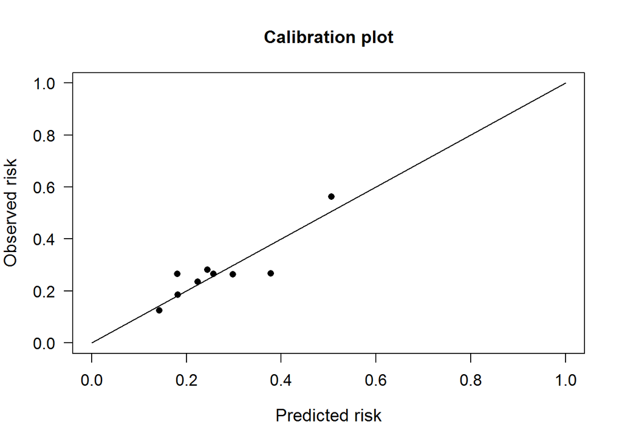

```
## $Table_HLtest
##               total meanpred meanobs predicted observed
## [0.105,0.181)    96    0.143   0.125     13.73       12
## 0.181            68    0.181   0.265     12.34       18
## 0.182            92    0.182   0.185     16.72       17
## [0.217,0.228)    17    0.224   0.235      3.80        4
## [0.228,0.248)    78    0.244   0.282     19.00       22
## [0.248,0.265)    34    0.257   0.265      8.74        9
## [0.265,0.344)    53    0.298   0.264     15.79       14
## [0.344,0.405)    41    0.378   0.268     15.50       11
## [0.405,0.740]    48    0.506   0.562     24.29       27
##
## $Chi_square
## [1] 7.089
##
## $df
## [1] 8
##
## $p_value
## [1] 0.527
```

```r
#I've had to remove NA values from the testing dataset in order for the Hosmer-Lemeshow test to run
testing <- filter(testing, !is.na(poms))

#Test the model with the testing dataset
library(PredictABEL)

(HL_lrpoms3 <- plotCalibration(data = testing,
                cOutcome = match("poms", colnames(testing)),
                predRisk = predict(lr_poms3, newdata = testing, type = "response")))
```

```r
#Calculate AUROC and plot the ROC curve
plotROC(data = testing,
        cOutcome = match("poms", colnames(testing)),
        predrisk = predict(lr_poms3, newdata = testing, type = "response"))
```

[output not shown]

```
## AUC [95% CI] for the model 1 :  0.628 [ 0.573  -  0.683 ]
```

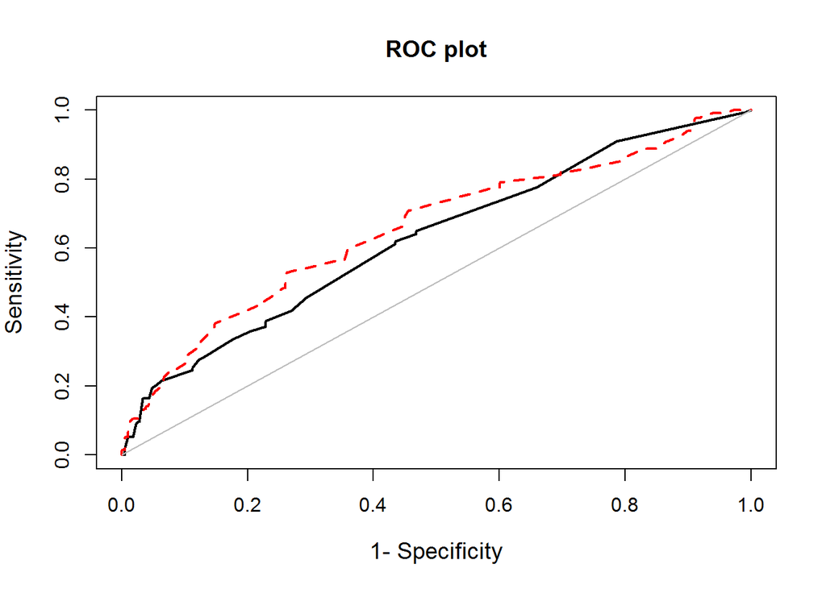

```
## AUC [95% CI] for the model 1 :  0.628 [ 0.573  -  0.683 ]
## AUC [95% CI] for the model 2 :  0.656 [ 0.601  -  0.712 ]
```

```r
#Let's overlay the ROC curve over the ROC curve for POSSUM-morbidity
plotROC(data = testing,
        cOutcome = match("poms", colnames(testing)),
        predrisk = cbind(predict(lr_poms3, newdata = testing, type = "response"),
                         testing$morb_poss))
```

```r
#Let's compare whether the new model is as good as POSSUM in discrimination
library(pROC)

#Create the ROC objects
x <- predict(lr_poms3, newdata = testing, type = "response") #Temp variable
roc_model3 <- roc(testing$poms ~ x, plot=FALSE, auc=TRUE, ci=TRUE)
roc_POSSUM <- roc(testing$poms ~ testing$morb_poss, plot=FALSE, auc=TRUE, ci=TRUE)

#Test the ROC objects against each other
roc.test(roc_model3, roc_POSSUM)
```

```
##
##  DeLong's test for two correlated ROC curves
##
## data:  roc_model3 and roc_POSSUM
## Z = -0.97032, p-value = 0.3319
## alternative hypothesis: true difference in AUC is not equal to 0
## sample estimates:
## AUC of roc1 AUC of roc2
##   0.6276917   0.6562322
```

```r
#library(rms) #This package contains many functions for regression modelling
#
#val.prob(p = predict(lr_poms3, newdata = testing, type = "response"), y = testing$poms, smooth = TRUE)
```

The AUROC for the Model 3 was **0.628** which implies the model doesn’t perform very well.

#### Regression Model 4

We can attempt another model by calculating the SORT risk score as a single regression variable.

```r
#We will use the same training and testing partitions as the previous model but this time create a new column called risk score
set.seed(123)
x <- createDataPartition(join7$poms, p = (2/3), list = FALSE, times = 1)
training <- join7[x, ]
testing <- join7[-x, ]

#Fit a model with the training dataset
lr_poms4 <- glm(poms ~ risk_score,
                data = training,
                family = binomial)

summary(lr_poms4)
```

```
##
## Call:
## glm(formula = poms ~ risk_score, family = binomial, data = training)
##
## Deviance Residuals:
##     Min       1Q   Median       3Q      Max
## -1.5186  -0.7025  -0.6327   1.0336   1.9240
##
## Coefficients:
##             Estimate Std. Error z value Pr(>|z|)
## (Intercept) -1.87920    0.13870  -13.55  < 2e-16 ***
## risk_score   0.52308    0.07254    7.21 5.58e-13 ***
## ---
## Signif. codes:  0 '***' 0.001 '**' 0.01 '*' 0.05 '.' 0.1 ' ' 1
##
## (Dispersion parameter for binomial family taken to be 1)
##
##     Null deviance: 1198.5  on 1055  degrees of freedom
## Residual deviance: 1145.3  on 1054  degrees of freedom
## AIC: 1149.3
##
## Number of Fisher Scoring iterations: 4
```

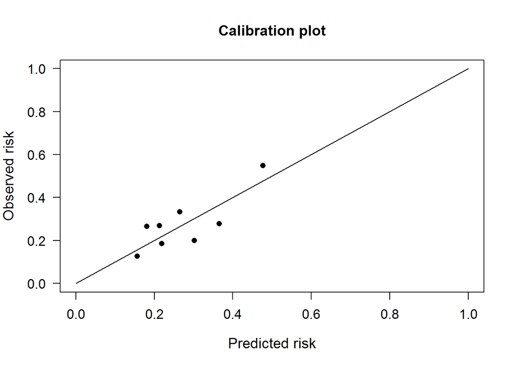

```
## $Table_HLtest
##               total meanpred meanobs predicted observed
## [0.132,0.181)    95    0.156   0.126     14.78       12
## 0.181            68    0.181   0.265     12.34       18
## [0.187,0.219)    78    0.213   0.269     16.58       21
## 0.219            92    0.219   0.185     20.12       17
## [0.239,0.284)    39    0.265   0.333     10.34       13
## [0.284,0.361)    50    0.302   0.200     15.11       10
## [0.361,0.383)    54    0.365   0.278     19.74       15
## [0.383,0.774]    51    0.477   0.549     24.35       28
##
## $Chi_square
## [1] 12.16
##
## $df
## [1] 8
##
## $p_value
## [1] 0.1442
```

```r
#I've had to remove NA values from the testing dataset in order for the Hosmer-Lemeshow test to run
testing <- filter(testing, !is.na(poms))

#Test the model with the testing dataset
plotCalibration(data = testing,
                cOutcome = match("poms", colnames(testing)),
                predRisk = predict(lr_poms4, newdata = testing, type = "response"))
```

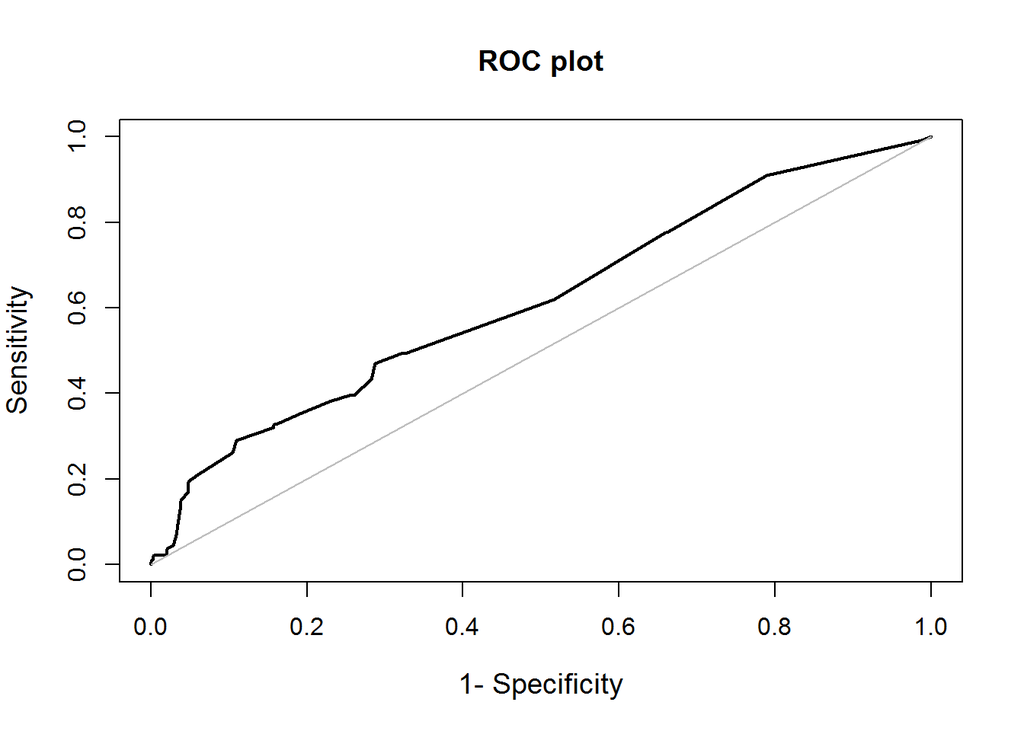

```
## AUC [95% CI] for the model 1 :  0.616 [ 0.56  -  0.671 ]
```

```r
#Calculate AUROC and plot the ROC curve
plotROC(data = testing,
        cOutcome = match("poms", colnames(testing)),
        predrisk = predict(lr_poms4, newdata = testing, type = "response"))
```

```r
#Let's compare whether the new model is as good as POSSUM in discrimination
library(pROC)

#Create the ROC objects
x <- predict(lr_poms4, newdata = testing, type = "response") #Temp variable
roc_model <- roc(testing$poms ~ x, plot=FALSE, auc=TRUE, ci=TRUE)
roc_POSSUM <- roc(testing$poms ~ testing$morb_poss, plot=FALSE, auc=TRUE, ci=TRUE)

#Test the ROC objects against each other
roc.test(roc_model, roc_POSSUM)
```

```
##
##  DeLong's test for two correlated ROC curves
##
## data:  roc_model and roc_POSSUM
## Z = -1.4241, p-value = 0.1544
## alternative hypothesis: true difference in AUC is not equal to 0
## sample estimates:
## AUC of roc1 AUC of roc2
##   0.6158995   0.6562322
```

The AUC doesn’t seem much better for this 4th model

#### Regression Model 5 - An alternative outcome measure

We have thus far been looking at POMS as an outcome measure and seeing how well the SORT variables predict morbidity as defined by that. What if we pick an alternative measure of morbidity. Readmission rates could be one such example

```
##
## Call:
## glm(formula = Followup_Readmission_30Days ~ (asa == 3) + (asa >=
##     4) + (opspecialty >= 2 & opspecialty < 6) + (op_severity >
##     7) + malignancy + (age >= 65 & age < 80) + (age >= 80), family = binomial,
##     data = training)
##
## Deviance Residuals:
##     Min       1Q   Median       3Q      Max
## -0.3686  -0.2432  -0.1859  -0.1401   3.0424
##
## Coefficients:
##                                         Estimate Std. Error z value
## (Intercept)                              -3.1125     0.6908  -4.506
## asa == 3TRUE                              0.4574     0.4970   0.920
## asa >= 4TRUE                            -14.1722  2014.9983  -0.007
## opspecialty >= 2 & opspecialty < 6TRUE   -1.1125     0.5705  -1.950
## op_severity > 7TRUE                      -0.3933     0.6485  -0.607
## malignancy                              -14.2487   868.7154  -0.016
## age >= 65 & age < 80TRUE                  0.1781     0.4608   0.386
## age >= 80TRUE                            -1.0008     1.0673  -0.938
##                                        Pr(>|z|)
## (Intercept)                            6.62e-06 ***
## asa == 3TRUE                             0.3574
## asa >= 4TRUE                             0.9944
## opspecialty >= 2 & opspecialty < 6TRUE   0.0512 .
## op_severity > 7TRUE                      0.5442
## malignancy                               0.9869
## age >= 65 & age < 80TRUE                 0.6992
## age >= 80TRUE                            0.3484
## ---
## Signif. codes:  0 '***' 0.001 '**' 0.01 '*' 0.05 '.' 0.1 ' ' 1
##
## (Dispersion parameter for binomial family taken to be 1)
##
##     Null deviance: 211.89  on 1009  degrees of freedom
## Residual deviance: 202.45  on 1002  degrees of freedom
##   (46 observations deleted due to missingness)
## AIC: 218.45
##
## Number of Fisher Scoring iterations: 17
```

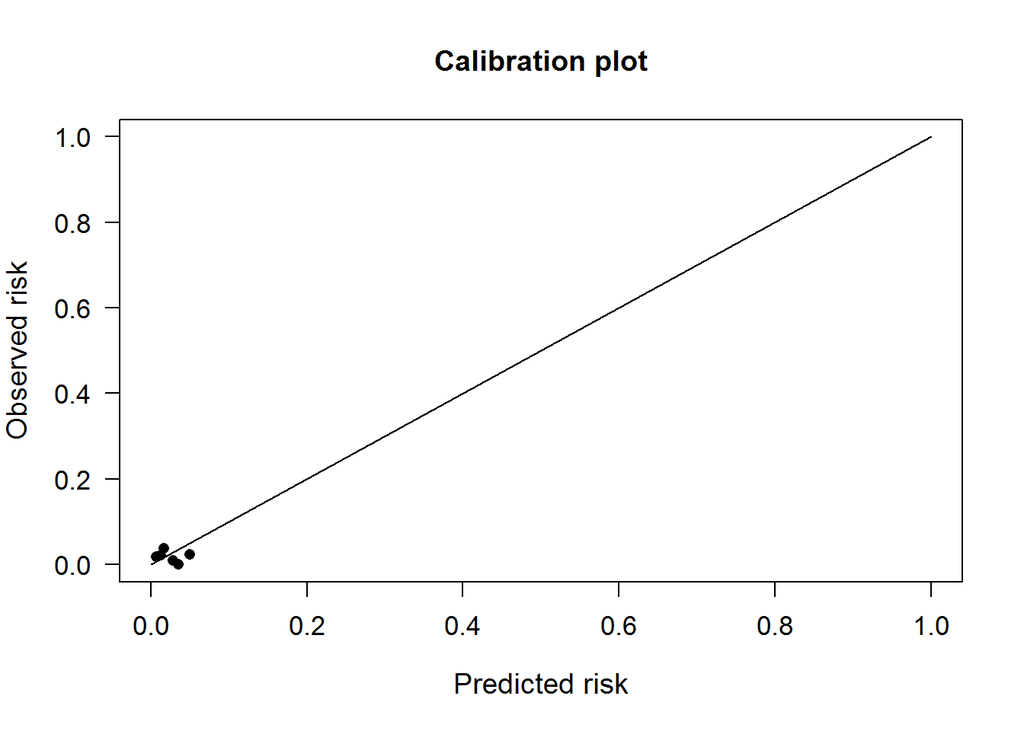

```
## $Table_HLtest
##                   total meanpred meanobs predicted observed
## [2.35e-09,0.0109)   112    0.007   0.018      0.73        2
## [1.09e-02,0.0154)    92    0.013   0.022      1.23        2
## [1.54e-02,0.0226)    52    0.017   0.038      0.87        2
## [2.26e-02,0.0346)   104    0.028   0.010      2.94        1
## 3.46e-02             89    0.035   0.000      3.08        0
## [4.26e-02,0.0775]    44    0.050   0.023      2.21        1
##
## $Chi_square
## [1] 9.23
##
## $df
## [1] 8
##
## $p_value
## [1] 0.3233
```

```
## AUC [95% CI] for the model 1 :  0.42 [ 0.222  -  0.619 ]
```

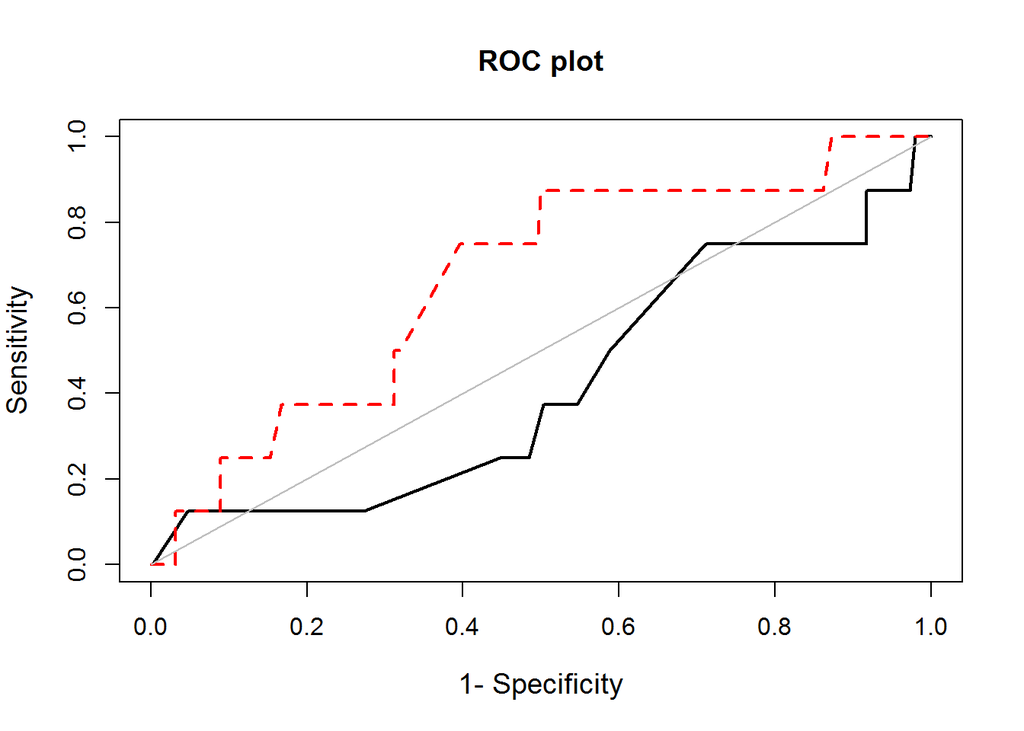

```
## AUC [95% CI] for the model 1 :  0.42 [ 0.222  -  0.619 ]
## AUC [95% CI] for the model 2 :  0.666 [ 0.492  -  0.841 ]
```

```
##
##  Bootstrap test for two correlated ROC curves
##
## data:  roc_model and roc_POSSUM
## D = -2.1118, boot.n = 2000, boot.stratified = 1, p-value = 0.0347
## alternative hypothesis: true difference in AUC is not equal to 0
## sample estimates:
## AUC of roc1 AUC of roc2
##   0.5737062   0.6604708
```

It may be that POMS at Day 7 or 8 may be too sensitive an outcome measure, as suggested by Ramani. We may therefore need to look at Day 14 or 15 POMS instead.

### Day 14 or 15 POMS

We will repeat what we did for Regression Model 3 above, but this time with Day 14 or 15 POMS as an outcome measure. This time I will not print the code that went into processing the data, to save space.

```
## join14
##
##  53  Variables      1753  Observations
## ---------------------------------------------------------------------------
## poms_id
##        n  missing distinct
##      215     1538      215
##
## lowest : 004178a3-755b-4653-9d06-f12cbcf77459 00709167-8651-4c95-be07-e6fe29734d26 00b165e3-c415-465c-97d6-2ee6f144d104 00eafe16-478e-4b49-8914-6ab567d52bad 0105ed9c-b450-4b7f-8698-c9568e9dcc02
## highest: fc934cb1-42ca-40f6-8a0b-cbf501eae1c4 fd41f555-f83f-4645-b7a7-471f368e7154 fd8a2ce9-ed7a-413b-861d-fdb87255b645 ff761e92-fa68-4bba-abc9-1eb0bf713146 ffe4409b-8bb1-4919-b4c4-a86a7d9b2411
## ---------------------------------------------------------------------------
## adm_id
##        n  missing distinct
##     1753        0     1753
##
## lowest : 00422cff-ddbe-49e6-a2d9-f4680c0945c2  00bea38f-af7b-4f5f-9655-1ab134c95571  00cea437-fd5a-45d4-859d-ddd7f48f3199  01125a5f-814c-4120-a298-ae6f27d43ef5  012d095b-6cf9-4b06-b7de-50b6d72277de
## highest: ff8455e0-44e3-470d-8e86-0893cc101bc0  ff962ad5-22e6-42e4-b35b-3e6cc03ea022  ff9d4b2f-08b0-4a74-8c24-af45b0472a18  ffb0f43c-c710-43b2-8f7b-620d68522a57  ffd1beee-09b8-4203-836b-2bd08ac472f5
## ---------------------------------------------------------------------------
## poms_day
##        n  missing distinct     Info     Mean      Gmd
##      215     1538        2    0.505    14.21   0.3379
##
## 14 (169, 0.786), 15 (46, 0.214)
## ---------------------------------------------------------------------------
## pulm
##        n  missing distinct
##     1753        0        2
##
## FALSE (1724, 0.983), TRUE (29, 0.017)
## ---------------------------------------------------------------------------
## inf
##        n  missing distinct
##     1753        0        2
##
## FALSE (1695, 0.967), TRUE (58, 0.033)
## ---------------------------------------------------------------------------
## renal
##        n  missing distinct
##     1753        0        2
##
```

[output cut: 298 more lines]

```
## srs_mort
##        n  missing distinct     Info     Mean      Gmd
##     1753        0        8     0.85  0.02056  0.01459
##
## lowest : 0.0006818628 0.0015780281 0.0036477148 0.0084090681 0.0192652326
## highest: 0.0084090681 0.0192652326 0.0435216350 0.0953494649 0.1962340564
##
## Value      0.0006818628 0.0015780281 0.0036477148 0.0084090681
## Frequency            41           65          110          301
## Proportion        0.023        0.037        0.063        0.172
##
## Value      0.0192652326 0.0435216350 0.0953494649 0.1962340564
## Frequency           909          305           21            1
## Proportion        0.519        0.174        0.012        0.001
## ---------------------------------------------------------------------------
```

#### Plots - Day 14 or 15 POMS Outcome

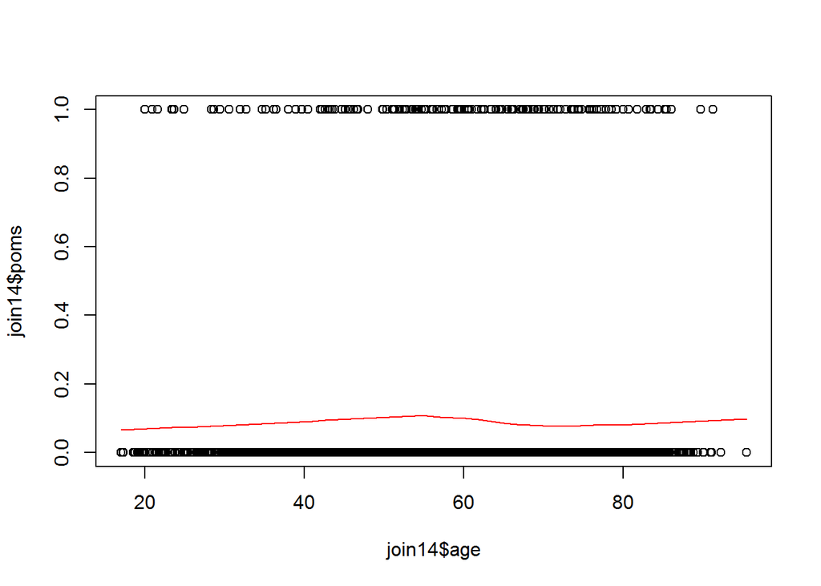

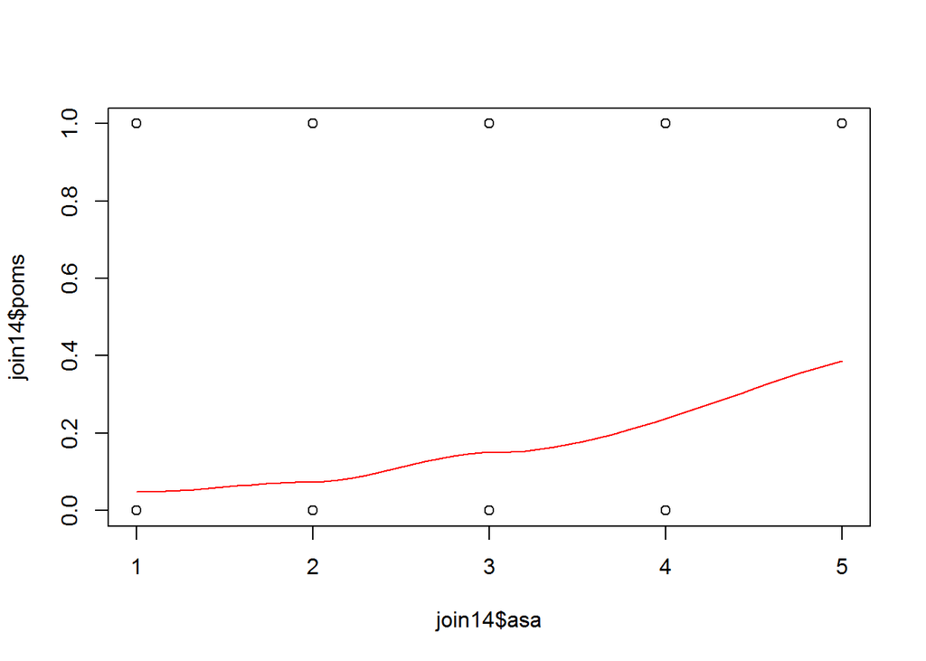

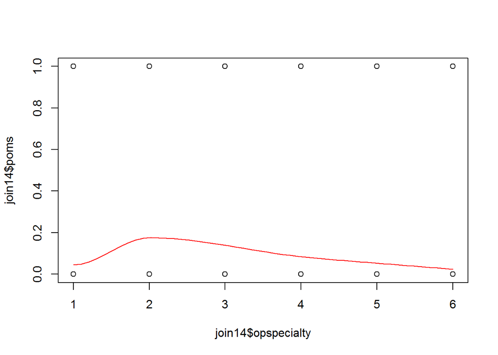

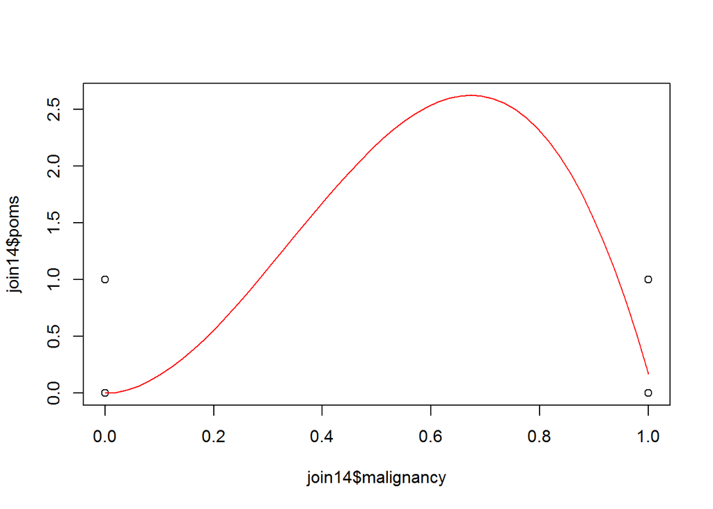

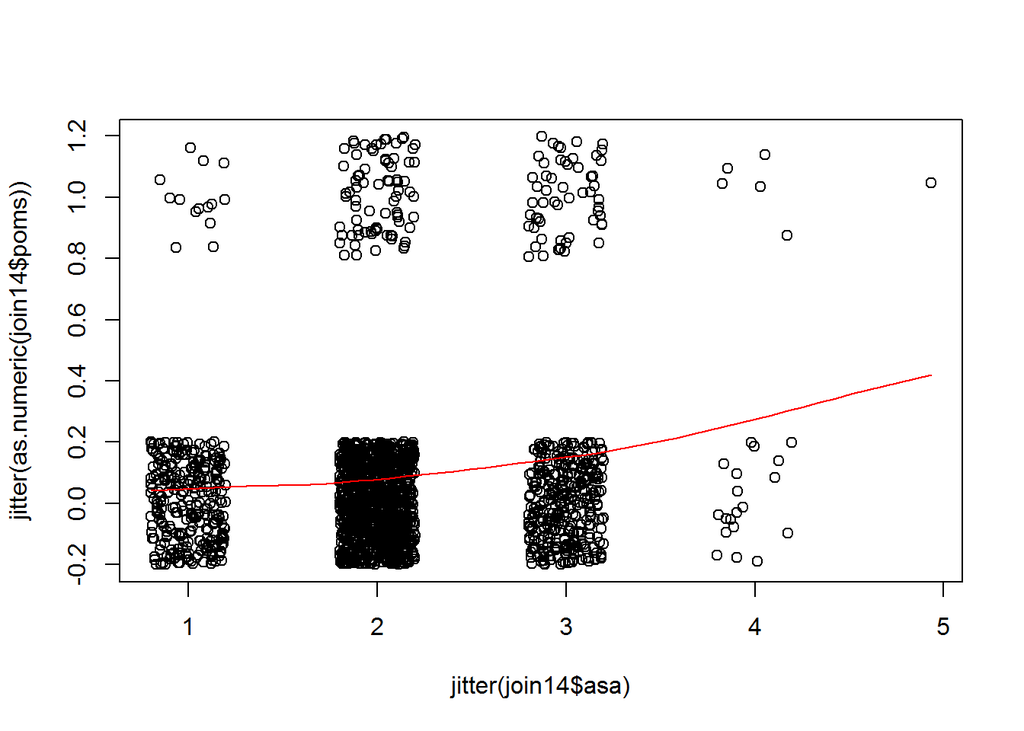

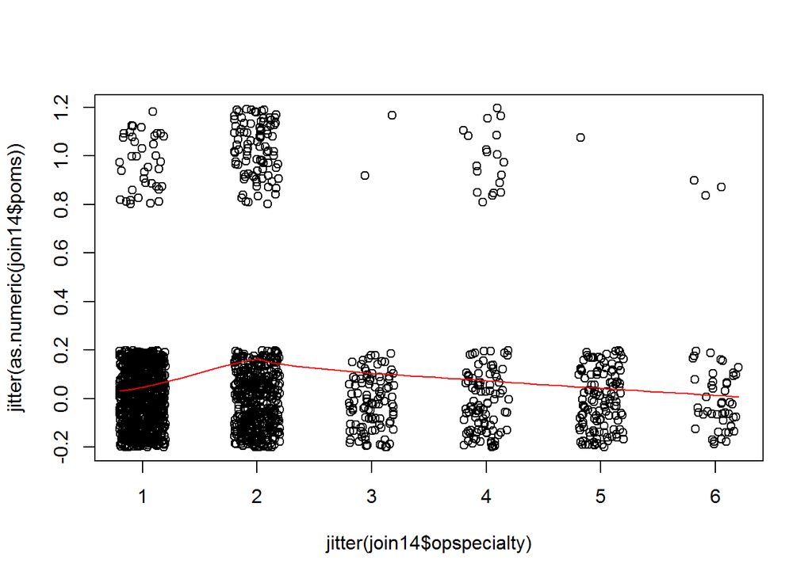

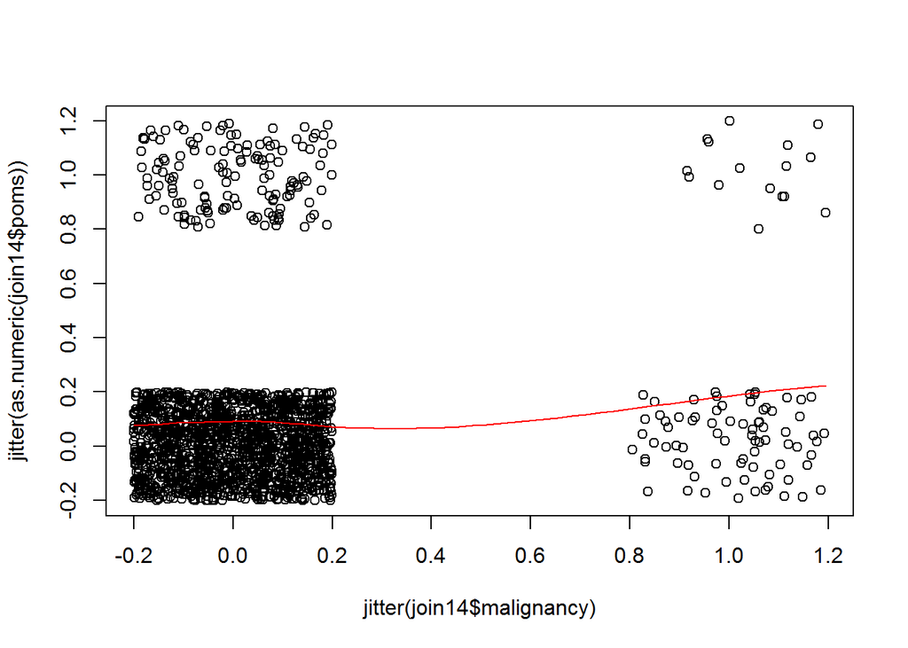

#### Regression Model 6

We now want to fit the model used in Regression Model 3, but to the Day 14 or 15 POMS outcomes.

```
## [1] 1056
```

```
## [1] 697
```

```
##
## Call:
## glm(formula = poms ~ (asa == 3) + (asa >= 4) + (opspecialty >=
##     2 & opspecialty < 6) + (op_severity > 7) + malignancy + (age >=
##     65 & age < 80) + (age >= 80), family = binomial, data = training)
##
## Deviance Residuals:
##     Min       1Q   Median       3Q      Max
## -0.7676  -0.4610  -0.2896  -0.2714   2.8951
##
## Coefficients: (1 not defined because of singularities)
##                                        Estimate Std. Error z value
## (Intercept)                             -3.4096     0.3997  -8.531
## asa == 3TRUE                             0.2609     0.3282   0.795
## asa >= 4TRUE                                 NA         NA      NA
## opspecialty >= 2 & opspecialty < 6TRUE   0.9842     0.3061   3.215
## op_severity > 7TRUE                      0.2591     0.3038   0.853
## malignancy                               1.0949     0.3911   2.800
## age >= 65 & age < 80TRUE                -0.1327     0.3035  -0.437
## age >= 80TRUE                           -1.0251     1.0324  -0.993
##                                        Pr(>|z|)
## (Intercept)                             < 2e-16 ***
## asa == 3TRUE                            0.42665
## asa >= 4TRUE                                 NA
## opspecialty >= 2 & opspecialty < 6TRUE  0.00130 **
## op_severity > 7TRUE                     0.39362
## malignancy                              0.00511 **
## age >= 65 & age < 80TRUE                0.66189
## age >= 80TRUE                           0.32073
## ---
## Signif. codes:  0 '***' 0.001 '**' 0.01 '*' 0.05 '.' 0.1 ' ' 1
##
## (Dispersion parameter for binomial family taken to be 1)
##
##     Null deviance: 541.26  on 1055  degrees of freedom
## Residual deviance: 512.17  on 1049  degrees of freedom
## AIC: 526.17
##
## Number of Fisher Scoring iterations: 6
```

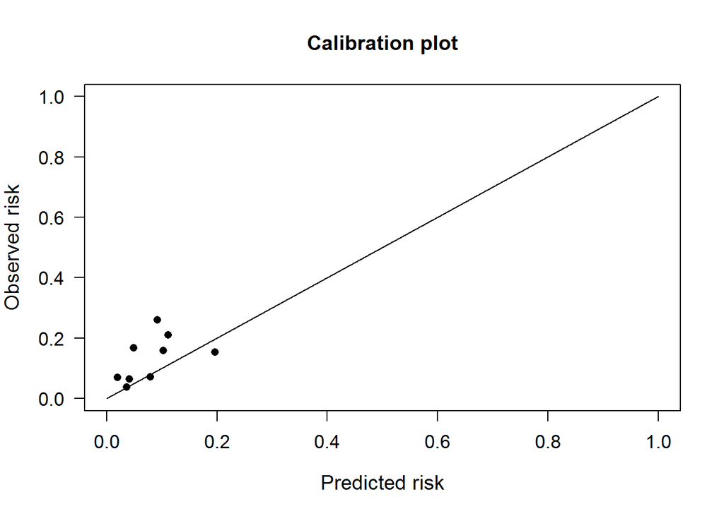

```
## $Table_HLtest
##                 total meanpred meanobs predicted observed
## [0.0117,0.0362)    72    0.020   0.069      1.42        5
## 0.0362            107    0.036   0.037      3.87        4
## [0.0395,0.0411)   125    0.041   0.064      5.10        8
## [0.0411,0.0719)    54    0.049   0.167      2.67        9
## [0.0719,0.0912)    84    0.079   0.071      6.66        6
## [0.0912,0.1028)    46    0.092   0.261      4.21       12
## 0.1028             88    0.103   0.159      9.05       14
## [0.1030,0.1270)    62    0.111   0.210      6.89       13
## [0.1270,0.3078]    59    0.196   0.153     11.56        9
##
## $Chi_square
## [1] 52.405
##
## $df
## [1] 8
##
## $p_value
## [1] 0
```

```
## AUC [95% CI] for the model 1 :  0.639 [ 0.579  -  0.7 ]
```

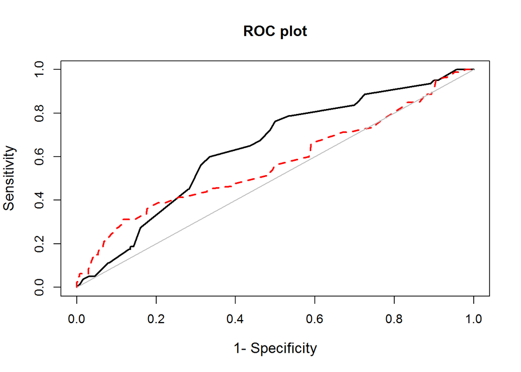

```
## AUC [95% CI] for the model 1 :  0.639 [ 0.579  -  0.7 ]
## AUC [95% CI] for the model 2 :  0.571 [ 0.497  -  0.645 ]
```

```
##
##  DeLong's test for two correlated ROC curves
##
## data:  roc_model and roc_POSSUM
## Z = 1.3028, p-value = 0.1926
## alternative hypothesis: true difference in AUC is not equal to 0
## sample estimates:
## AUC of roc1 AUC of roc2
##   0.6393841   0.5709481
```

### Further refining the Regression Models

If we look at the scatter plots in the earlier parts of the analysis, particularly the one of POMS vs Surgical Specialty, the relationship between POMS and the surgical specialty doesn’t seem very strong for the patients who underwent Upper GI, Vascular, Bariatric or Other surgery (`opspecialty 3-6`). The strongest predictor appears to be Colorectal surgery out of those specialties. Therefore it may be better to fit a more restricted model.

#### Regression Model 7

```
## [1] 1056
```

```
## [1] 527
```

```
##
## Call:
## glm(formula = poms ~ (asa == 3) + (asa >= 4) + (opspecialty ==
##     2 | opspecialty == 3) + (op_severity > 7) + malignancy +
##     (age >= 65 & age < 80) + (age >= 80), family = binomial,
##     data = training)
##
## Deviance Residuals:
##     Min       1Q   Median       3Q      Max
## -1.7757  -0.7483  -0.6270   0.6805   2.3167
##
## Coefficients:
##                                         Estimate Std. Error z value
## (Intercept)                              -2.6129     0.2536 -10.302
## asa == 3TRUE                              0.7520     0.1693   4.442
## asa >= 4TRUE                              1.1225     0.6668   1.684
## opspecialty == 2 | opspecialty == 3TRUE   1.1705     0.1852   6.320
## op_severity > 7TRUE                       0.7310     0.2091   3.496
## malignancy                                0.9492     0.3033   3.129
## age >= 65 & age < 80TRUE                  0.3550     0.1738   2.043
## age >= 80TRUE                             0.8318     0.2471   3.366
##                                         Pr(>|z|)
## (Intercept)                              < 2e-16 ***
## asa == 3TRUE                            8.93e-06 ***
## asa >= 4TRUE                            0.092267 .
## opspecialty == 2 | opspecialty == 3TRUE 2.61e-10 ***
## op_severity > 7TRUE                     0.000472 ***
## malignancy                              0.001754 **
## age >= 65 & age < 80TRUE                0.041045 *
## age >= 80TRUE                           0.000763 ***
## ---
## Signif. codes:  0 '***' 0.001 '**' 0.01 '*' 0.05 '.' 0.1 ' ' 1
##
## (Dispersion parameter for binomial family taken to be 1)
##
##     Null deviance: 1198.5  on 1055  degrees of freedom
## Residual deviance: 1099.4  on 1048  degrees of freedom
## AIC: 1115.4
##
## Number of Fisher Scoring iterations: 4
```

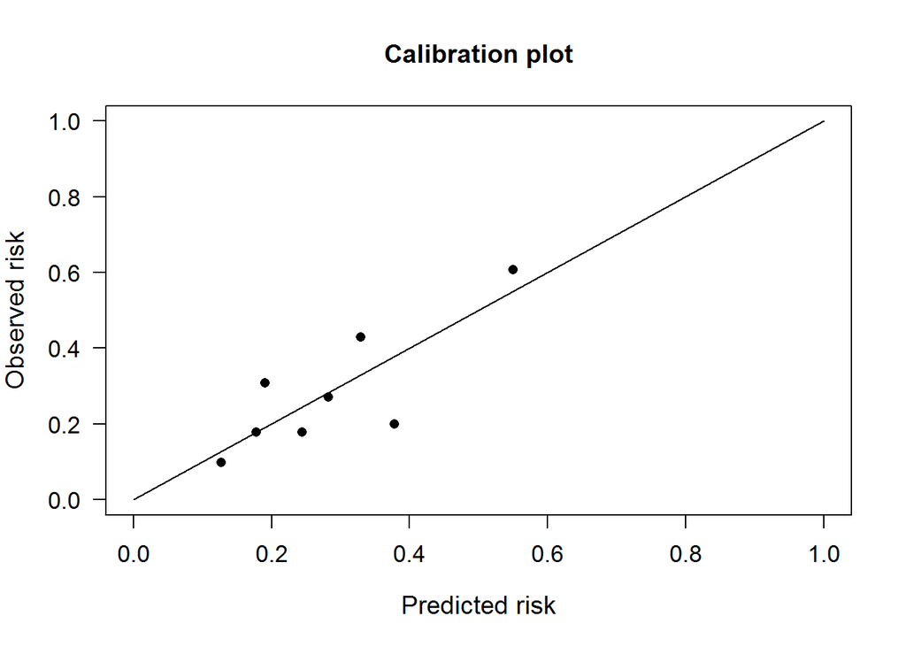

```
## $Table_HLtest
##                total meanpred meanobs predicted observed
## [0.0683,0.135)   131    0.127   0.099     16.67       13
## [0.1346,0.182)    95    0.178   0.179     16.91       17
## [0.1816,0.244)    68    0.191   0.309     12.97       21
## 0.2442            28    0.244   0.179      6.84        5
## [0.2521,0.319)    70    0.282   0.271     19.73       19
## [0.3188,0.334)    49    0.329   0.429     16.10       21
## [0.3340,0.421)    35    0.378   0.200     13.22        7
## [0.4207,0.793]    51    0.550   0.608     28.04       31
##
## $Chi_square
## [1] 15.373
##
## $df
## [1] 8
##
## $p_value
## [1] 0.0523
```

```
## AUC [95% CI] for the model 1 :  0.689 [ 0.638  -  0.74 ]
```

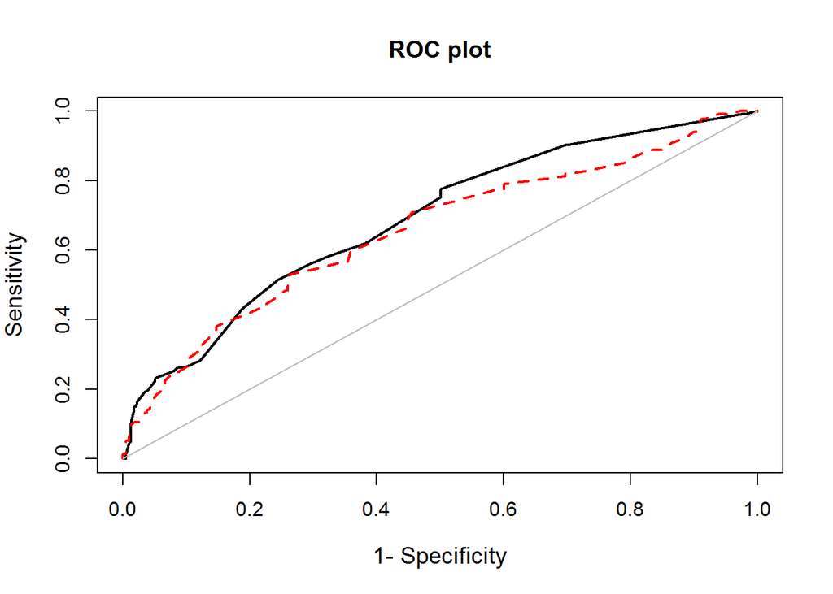

```
## AUC [95% CI] for the model 1 :  0.689 [ 0.638  -  0.74 ]
## AUC [95% CI] for the model 2 :  0.656 [ 0.601  -  0.712 ]
```

```
##
##  DeLong's test for two correlated ROC curves
##
## data:  roc_model7 and roc_POSSUM
## Z = 1.0148, p-value = 0.3102
## alternative hypothesis: true difference in AUC is not equal to 0
## sample estimates:
## AUC of roc1 AUC of roc2
##   0.6888933   0.6562322
```

It seems that the AUROC has improved with this more restricted model.

#### Regression Model 8

We will now do the same as Regression Model 7, but changing surgical specialty into factor variable

```
## [1] 1056
```

```
## [1] 527
```

```
##
## Call:
## glm(formula = poms ~ (asa == 3) + (asa >= 4) + factor(opspecialty) +
##     (op_severity > 7) + malignancy + (age >= 65 & age < 80) +
##     (age >= 80), family = binomial, data = training)
##
## Deviance Residuals:
##     Min       1Q   Median       3Q      Max
## -1.9873  -0.6763  -0.5706   0.6051   2.8527
##
## Coefficients:
##                          Estimate Std. Error z value Pr(>|z|)
## (Intercept)               -3.0150     0.2858 -10.551  < 2e-16 ***
## asa == 3TRUE               0.8756     0.1794   4.882 1.05e-06 ***
## asa >= 4TRUE               0.9391     0.7171   1.310  0.19034
## factor(opspecialty)2       1.6562     0.2212   7.489 6.95e-14 ***
## factor(opspecialty)3      -0.9048     0.4390  -2.061  0.03928 *
## factor(opspecialty)4       0.3053     0.3170   0.963  0.33545
## factor(opspecialty)5      -1.0367     0.4537  -2.285  0.02232 *
## factor(opspecialty)6       0.1778     0.5294   0.336  0.73702
## op_severity > 7TRUE        1.2822     0.2314   5.541 3.01e-08 ***
## malignancy                 0.8847     0.3267   2.708  0.00677 **
## age >= 65 & age < 80TRUE   0.1415     0.1818   0.778  0.43637
## age >= 80TRUE              0.5735     0.2547   2.252  0.02433 *
## ---
## Signif. codes:  0 '***' 0.001 '**' 0.01 '*' 0.05 '.' 0.1 ' ' 1
##
## (Dispersion parameter for binomial family taken to be 1)
##
##     Null deviance: 1198.5  on 1055  degrees of freedom
## Residual deviance: 1044.5  on 1044  degrees of freedom
## AIC: 1068.5
##
## Number of Fisher Scoring iterations: 5
```

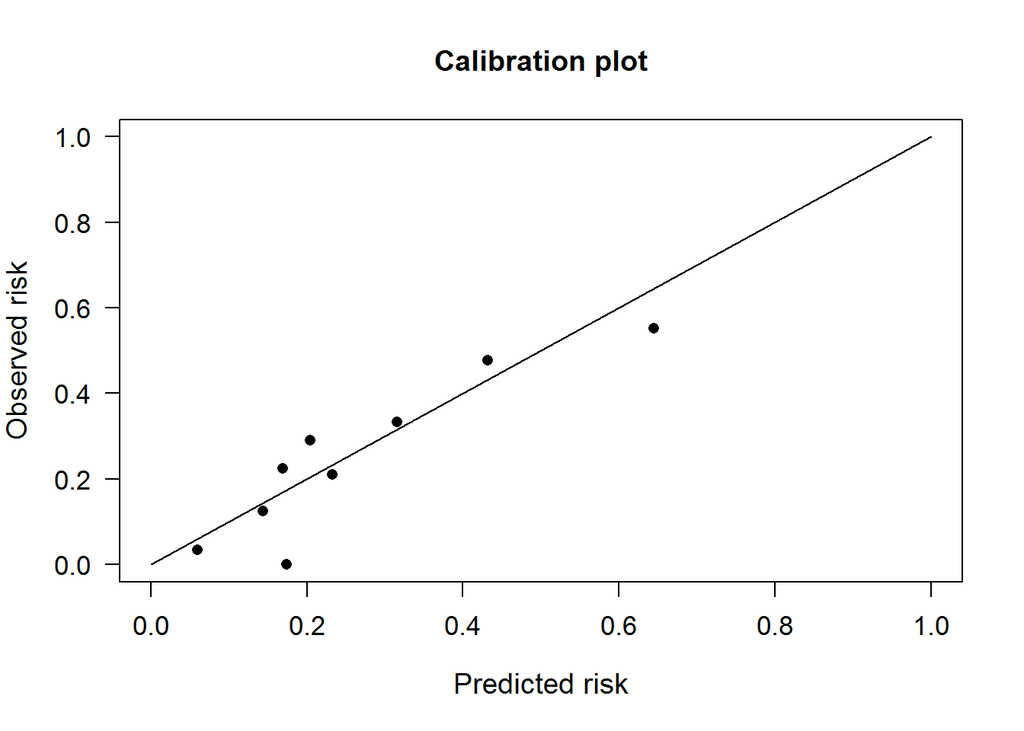

```
## AUC [95% CI] for the model 1 :  0.717 [ 0.667  -  0.766 ]
```

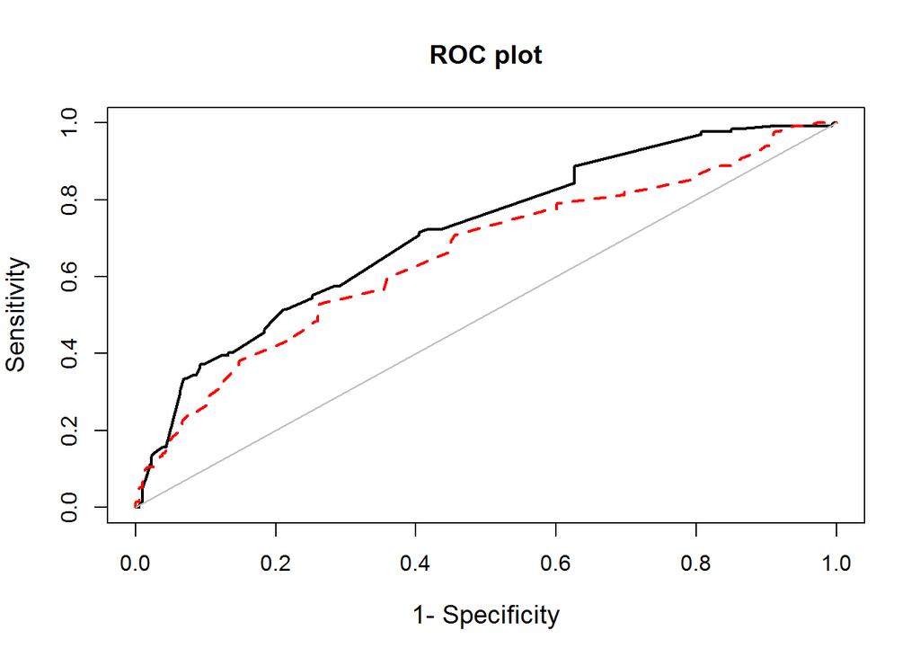

```
## AUC [95% CI] for the model 1 :  0.717 [ 0.667  -  0.766 ]
## AUC [95% CI] for the model 2 :  0.656 [ 0.601  -  0.712 ]
```

```
##
##  DeLong's test for two correlated ROC curves
##
## data:  roc_model8 and roc_POSSUM
## Z = 1.8385, p-value = 0.06599
## alternative hypothesis: true difference in AUC is not equal to 0
## sample estimates:
## AUC of roc1 AUC of roc2
##   0.7165129   0.6562322
```

#### Regression Model 9

Regression Model 8, but change the ASA to dummy variables, ASA == 2, ASA == 3 or ASA >= 4.

```
## [1] 1056
```

```
## [1] 527
```

```
##
## Call:
## glm(formula = poms ~ (asa == 2) + (asa == 3) + (asa >= 4) + factor(opspecialty) +
##     (op_severity > 7) + malignancy + (age >= 65 & age < 80) +
##     (age >= 80), family = binomial, data = training)
##
## Deviance Residuals:
##     Min       1Q   Median       3Q      Max
## -1.9860  -0.7118  -0.5906   0.5962   2.8211
##
## Coefficients:
##                          Estimate Std. Error z value Pr(>|z|)
## (Intercept)               -3.2281     0.3250  -9.932  < 2e-16 ***
## asa == 2TRUE               0.3323     0.2287   1.453  0.14626
## asa == 3TRUE               1.1395     0.2574   4.426 9.58e-06 ***
## asa >= 4TRUE               1.2231     0.7431   1.646  0.09978 .
## factor(opspecialty)2       1.6579     0.2213   7.491 6.83e-14 ***
## factor(opspecialty)3      -0.9294     0.4392  -2.116  0.03431 *
## factor(opspecialty)4       0.2962     0.3163   0.937  0.34898
## factor(opspecialty)5      -1.0647     0.4541  -2.345  0.01904 *
## factor(opspecialty)6       0.1807     0.5303   0.341  0.73324
## op_severity > 7TRUE        1.2378     0.2332   5.308 1.11e-07 ***
## malignancy                 0.8968     0.3279   2.735  0.00624 **
## age >= 65 & age < 80TRUE   0.1182     0.1826   0.647  0.51753
## age >= 80TRUE              0.5500     0.2552   2.155  0.03115 *
## ---
## Signif. codes:  0 '***' 0.001 '**' 0.01 '*' 0.05 '.' 0.1 ' ' 1
##
## (Dispersion parameter for binomial family taken to be 1)
##
##     Null deviance: 1198.5  on 1055  degrees of freedom
## Residual deviance: 1042.3  on 1043  degrees of freedom
## AIC: 1068.3
##
## Number of Fisher Scoring iterations: 5
```

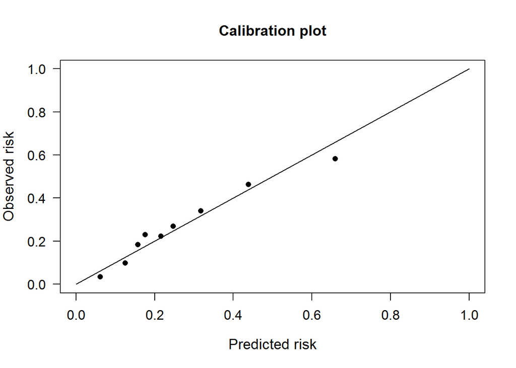

```
## AUC [95% CI] for the model 1 :  0.717 [ 0.668  -  0.766 ]
```

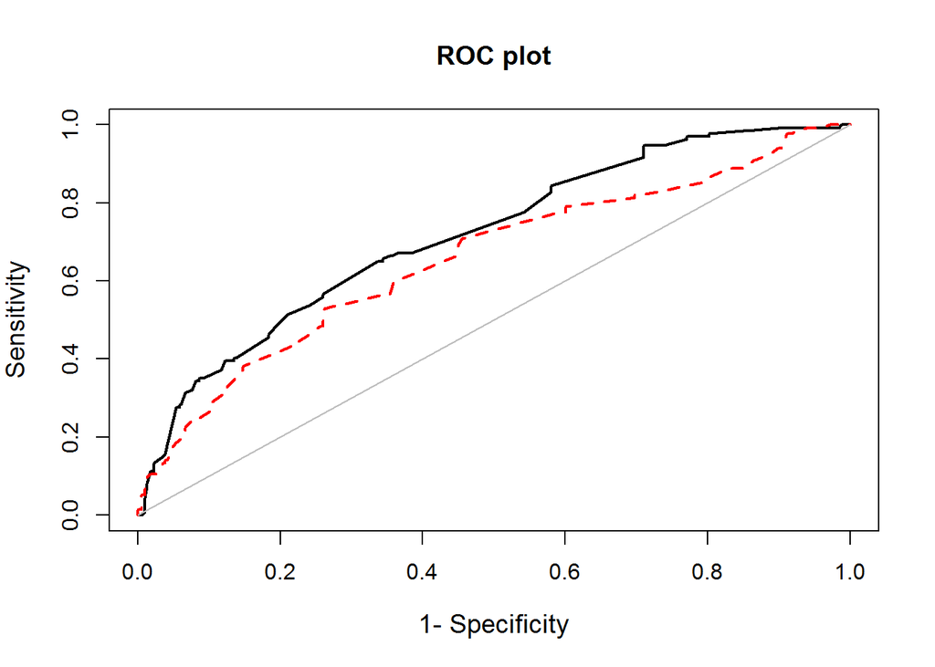

```
## AUC [95% CI] for the model 1 :  0.717 [ 0.668  -  0.766 ]
## AUC [95% CI] for the model 2 :  0.656 [ 0.601  -  0.712 ]
```

```
##
##  DeLong's test for two correlated ROC curves
##
## data:  roc_model9 and roc_POSSUM
## Z = 1.8521, p-value = 0.06401
## alternative hypothesis: true difference in AUC is not equal to 0
## sample estimates:
## AUC of roc1 AUC of roc2
##   0.7169971   0.6562322
```